# The Exponential Cost of Time When In a Life or Death Emergency: The Struggle for Healthcare Accessability in Rural America

Group 02: X & Y

[figure not shown]

# Rural Healthcare

##Starting the Conversation: Why are Hospitals important in Massachusetts?

There is a prevelant issue of rural populations having a lack of access to health services and emergency resources across the country. This is incredibly troublesome as death and serious injury accidents consist of a whopping [60 percent of total rural accidents versus only 48 percent of urban](https://www.ruralhealthweb.org/getattachment/Advocate/Policy-Documents/FutureofRuralHealthFeb-2013.pdf.aspx). These serious injury accidents can cause a [higher rate of morbidity and mortality](https://www.ruralhealthweb.org/getattachment/Advocate/Policy-Documents/FutureofRuralHealthFeb-2013.pdf.aspx) due to the severly long delays in calling for an EMS provider and the longer distance required to get oneself to a hospital for emergency treatment. In this blogpost we want to investigate if this same national absence of emergency healthcare providers exists in Massachusetts and if existing public policy supports emergency rural healthcare. We used datafrom the [Homeland Infrastructure Foundation-Level Data](https://hifld-geoplatform.opendata.arcgis.com/datasets/hospitals?geometry=-224.813%2C7.236%2C28.312%2C56.489) providing geospatial data and characteristics of hospitals around the US collected from State departments and Federal sources. We also used data from the [US Census Bureau](https://www.census.gov/programs-surveys/decennial-census/data/datasets.2010.html) that gives us the population density data for Massachusetts from their Decennial national collection of population and housing statistics to see if current hospitals are currently meeting MA constituents’ needs.

# Massachusetts Hospital Size and Distribution Across the State

The map below shows “Critical Access” and “General Acute Care Hospitals” in other words hospitals equipped to handle a civillian emergency (as these are the most prevalent rural accidents) and are color coded and sized so that each point represents a range of the number of available beds.Beds are used as a proxy for capacity with the lighter and smaller points connoting a hospital with a small capacity and the bigger and darker points representing a larger capacity hospital.

[interactive chart not shown]

As visualized on the map, there are large gaps between hospital coverage the farther west one moves in the state, and with a smaller capacity, save for the exception of Springfield. Additionally, looking at the bordering states, there are very few hospitals closer to the state lines that Massachusetts residents could potentially drive to as closer alternative. Also important to note is that there are no Critical Access hospitals, which are typically smaller in size and sophistication established to serve as an immediate resource for those in rural communities.

# Do Existing Hospitals Keep up with Existing Population Demand?

The next logical question to ask given the large dinstances between emergency hospital locations across the state is whether these existing hospitals are able to meet the current demands of the population. To investigate this relationship, the map below plots the population density of Massachusetts (where a greater population is represented by a lighter color) and varying red points representing hospital capacity.

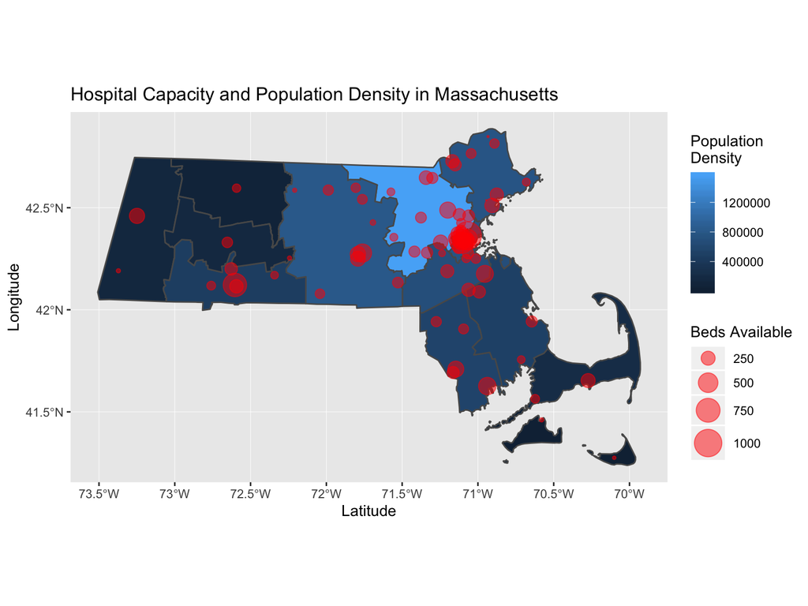

From this graph we can observe that the population is less dense in the farther west counties (than the East coast), and are populated by a smaller number of relatively small hospitals. However, the large gaps in distance between hospitals in the West is not offset by having a larger sized-hospital, as seen in the farthest left county. The most effective solution of care to accomodate for the less-dense populations is to have a greater number of small occupancy hospitals/emergency care locations as even though the population is smaller, rural residents still have to drive a farther distance and on less direct routes–zooming in on the previous map will show how hospitals are set up near major highways and are not as accessible for those who live farther from them).

#Who Owns Hospitals in MA and Surrounding States?

The next question is analyzing the current government involvement in hospitals by charting hospital owners in the state and whether the Government is an active sponsor. The colors in the graph below are assigned with purple representing Non-Profit, orange for proprietary, and green for government.

[interactive chart not shown]

As seen in the notably purple graph, only two hospitals in the state are owned by a government entity as seen in the two Cambridge Health Aliance chains near Boston, and these are classified as non-state government. This lacking absense of state government sponsorship of hospitals, reveals an opporunity for the government to intervene.

#Takeaways

Based on our findings above, we urge the Massachusetts state government to consider putting some of the increase of the[$340 million dollar unexpected increase](https://www.masslive.com/politics/index.ssf/2018/07/heres_how_the_4188_billion_sta.html)in the 2019 Fiscal budget to sustain and support constituents who are the most in need - those vulnerable and need of access to emergency response services. This can be put toward establishing or funding more Critical Access hospitals as there are *none* in the state (denoted in the data), and severely behind other states, especially in the West. Another policy option is to provide incentives to new graduates to establish and set up their practices in rural areas through [tax breaks or loan forgiveness programs](http://www.wrvo.org/post/rural-areas-struggle-health-care-availability), or by sponsoring a [J-1 visa program](https://j1visa.state.gov/programs/physician#participants) to incentivize foreign doctors to practice in rural MA areas. Another action is to even solidify reliable, not exponentially expensive access for rural community members to travel to existing hospitals (such as funding or subsidizing ambulances with tax-payer funds). As a voter/resident of MA, we urge you to vote on any proposed ballot measures to increase spending for healthcare and health access and be vigilant in your contact with your representatives to bring their attention to the importance of this issue.

#References and Citations

*[Hospital Data](https://hifld-geoplatform.opendata.arcgis.com/datasets/hospitals?geometry=-224.813%2C7.236%2C28.312%2C56.489), U.S. Department of Homeland Security, 2017.

*[Can I Use My Health Insurance Plan Outside of My State?](https://help.ihealthagents.com/hc/en-us/articles/224360547-Can-I-Use-My-Health-Insurance-Plan-Outside-of-My-State-), iHealthAgents, December 2, 2018.

*[Here’s how the $41.88 billion Massachusetts state budget would be spent](https://www.masslive.com/politics/index.ssf/2018/07/heres_how_the_4188_billion_sta.html), MassLive, July 18, 2018.

*[Exchange Visitor Program](https://j1visa.state.gov/programs/physician#participants),US Department of State.

*Ambulance trips can leave you with surprising — and very expensive — bills, Washington Post, November 20, 2017.

*[Image Citation](http://www.healthmediapolicy.com/wp-content/uploads/2017/05/RuralHospital.jpg), Health Media Policy, nd.

*[Census Data](https://www.census.gov/programs-surveys/decennial-census/data/datasets.2010.html), United States Census Bureau.

*[National Rural Health Association Policy Brief](https://www.ruralhealthweb.org/getattachment/Advocate/Policy-Documents/FutureofRuralHealthFeb-2013.pdf.aspx), National Rural Health Association, February 2013.